# python_overview

### Sorting

```python
df.sort_values(by=["MILES*"],ascending=False).head(5)
```

|  | START_DATE* | END_DATE* | CATEGORY* | START* | STOP* | MILES* | PURPOSE* |
| --- | --- | --- | --- | --- | --- | --- | --- |
| 1155 | Totals | NaN | NaN | NaN | NaN | 12204.7 | NaN |
| 269 | 3/25/2016 16:52 | 3/25/2016 22:22 | Business | Latta | Jacksonville | 310.3 | Customer Visit |
| 270 | 3/25/2016 22:54 | 3/26/2016 1:39 | Business | Jacksonville | Kissimmee | 201.0 | Meeting |
| 881 | 10/30/2016 15:22 | 10/30/2016 18:23 | Business | Asheville | Mebane | 195.9 | NaN |
| 776 | 9/27/2016 21:01 | 9/28/2016 2:37 | Business | Unknown Location | Unknown Location | 195.6 | NaN |

```python
df.sort_values(by=["START*", "MILES*"],ascending=[True,False]).head(5)
```

|  | START_DATE* | END_DATE* | CATEGORY* | START* | STOP* | MILES* | PURPOSE* |
| --- | --- | --- | --- | --- | --- | --- | --- |
| 906 | 11/4/2016 21:04 | 11/4/2016 21:20 | Business | Agnew | Cory | 4.3 | NaN |
| 911 | 11/6/2016 10:50 | 11/6/2016 11:04 | Business | Agnew | Renaissance | 2.4 | NaN |
| 908 | 11/5/2016 8:34 | 11/5/2016 8:43 | Business | Agnew | Renaissance | 2.2 | NaN |
| 910 | 11/5/2016 19:20 | 11/5/2016 19:28 | Business | Agnew | Agnew | 2.2 | NaN |
| 879 | 10/30/2016 12:58 | 10/30/2016 13:18 | Business | Almond | Bryson City | 15.2 | NaN |

### Conditionally adding columns

```python
import numpy as np
df["miles_cat"] = np.where(df["MILES*"] > 5,"Long Trip","Short Trip")
# after the condition, the value that you give is the value that will occur in the new column if
#the condition is satisfied(i.e) here, "Long trip"
# the value that is given at the end i.e) short trip here, is the value that would be populated in
#the new column when the condition is not satisfied.
```

```python
df.head()
```

|  | START_DATE* | END_DATE* | CATEGORY* | START* | STOP* | MILES* | PURPOSE* | miles_cat |
| --- | --- | --- | --- | --- | --- | --- | --- | --- |
| 0 | 1/1/2016 21:11 | 1/1/2016 21:17 | Business | Fort Pierce | Fort Pierce | 5.1 | Meal/Entertain | Long Trip |
| 1 | 1/2/2016 1:25 | 1/2/2016 1:37 | Business | Fort Pierce | Fort Pierce | 5.0 | NaN | Short Trip |
| 2 | 1/2/2016 20:25 | 1/2/2016 20:38 | Business | Fort Pierce | Fort Pierce | 4.8 | Errand/Supplies | Short Trip |
| 3 | 1/5/2016 17:31 | 1/5/2016 17:45 | Business | Fort Pierce | Fort Pierce | 4.7 | Meeting | Short Trip |
| 4 | 1/6/2016 14:42 | 1/6/2016 15:49 | Business | Fort Pierce | West Palm Beach | 63.7 | Customer Visit | Long Trip |

```python
df["miles_cat"].value_counts()
```

```
Long Trip     654
Short Trip    502
Name: miles_cat, dtype: int64
```

```python
df.loc[df["MILES*"] > 5].shape
```

```
(654, 8)
```

## In class Assignment

Create a new column with the following condition:

a) > 10 - Long Trip

b) 5 - 10 - Medium

c) < 5 - Short Trip

### Groupby Summarize

```python
df['START*'].value_counts().unique()
```

```
array([201, 148,  85,  68,  57,  37,  36,  28,  27,  17,  16,  14,  11,
        10,   9,   8,   7,   6,   5,   4,   3,   2,   1], dtype=int64)
```

```python
df_grp = df.groupby("START*")
print(type(df_grp))
```

```
<class 'pandas.core.groupby.generic.DataFrameGroupBy'>
```

```python
df_grp.count()
```

| START* | START_DATE* | END_DATE* | CATEGORY* | STOP* | MILES* | PURPOSE* |
| --- | --- | --- | --- | --- | --- | --- |
| Agnew | 4 | 4 | 4 | 4 | 4 | 0 |
| Almond | 1 | 1 | 1 | 1 | 1 | 0 |
| Apex | 17 | 17 | 17 | 17 | 17 | 11 |
| Arabi | 1 | 1 | 1 | 1 | 1 | 1 |
| Arlington | 1 | 1 | 1 | 1 | 1 | 0 |
| ... | ... | ... | ... | ... | ... | ... |
| West University | 2 | 2 | 2 | 2 | 2 | 1 |
| Weston | 2 | 2 | 2 | 2 | 2 | 1 |
| Westpark Place | 17 | 17 | 17 | 17 | 17 | 5 |
| Whitebridge | 68 | 68 | 68 | 68 | 68 | 36 |
| Winston Salem | 1 | 1 | 1 | 1 | 1 | 1 |

177 rows × 6 columns

```python
df.groupby("START*").count()
```

| START* | START_DATE* | END_DATE* | CATEGORY* | STOP* | MILES* | PURPOSE* | miles_cat |
| --- | --- | --- | --- | --- | --- | --- | --- |
| Agnew | 4 | 4 | 4 | 4 | 4 | 4 | 4 |
| Almond | 1 | 1 | 1 | 1 | 1 | 1 | 1 |
| Apex | 17 | 17 | 17 | 17 | 17 | 17 | 17 |
| Arabi | 1 | 1 | 1 | 1 | 1 | 1 | 1 |
| Arlington | 1 | 1 | 1 | 1 | 1 | 1 | 1 |
| ... | ... | ... | ... | ... | ... | ... | ... |
| West University | 2 | 2 | 2 | 2 | 2 | 2 | 2 |
| Weston | 2 | 2 | 2 | 2 | 2 | 2 | 2 |
| Westpark Place | 17 | 17 | 17 | 17 | 17 | 17 | 17 |
| Whitebridge | 68 | 68 | 68 | 68 | 68 | 68 | 68 |
| Winston Salem | 1 | 1 | 1 | 1 | 1 | 1 | 1 |

177 rows × 7 columns

Agnew - 4 trips have been made from Agnew

Average distance covered in these 4 trips

```python
# for each start loc find the mean distance travelled
df.groupby("START*")["MILES*"].agg("mean").head(25)
```

```
START*
Agnew                          2.775000
Almond                        15.200000
Apex                           5.341176
Arabi                         17.000000
Arlington                      4.900000
Arlington Park at Amberly      1.300000
Asheville                    143.850000
Austin                       136.000000
Banner Elk                    12.375000
Bellevue                      12.900000
Berkeley                      14.375000
Boone                        102.000000
Briar Meadow                   9.600000
Bryson City                   20.820000
Burtrose                       4.800000
CBD                            3.850000
Capitol One                    9.450000
Cary                           8.911940
Central                        1.950000
Chalmette                      1.100000
Chapel Hill                   20.150000
Chessington                    3.350000
College Avenue                 2.600000
Colombo                        5.100000
Columbia Heights               1.500000
Name: MILES*, dtype: float64
```

```python
# for each start loc find the mean & the total dist travelled
df.groupby("START*")["MILES*"].agg(["mean","sum"]).head(25)
```

| START* | mean | sum |
| --- | --- | --- |
| Agnew | 2.775000 | 11.1 |
| Almond | 15.200000 | 15.2 |
| Apex | 5.341176 | 90.8 |
| Arabi | 17.000000 | 17.0 |
| Arlington | 4.900000 | 4.9 |
| Arlington Park at Amberly | 1.300000 | 1.3 |
| Asheville | 143.850000 | 287.7 |
| Austin | 136.000000 | 136.0 |
| Banner Elk | 12.375000 | 99.0 |
| Bellevue | 12.900000 | 12.9 |
| Berkeley | 14.375000 | 230.0 |
| Boone | 102.000000 | 204.0 |
| Briar Meadow | 9.600000 | 9.6 |
| Bryson City | 20.820000 | 104.1 |
| Burtrose | 4.800000 | 4.8 |
| CBD | 3.850000 | 15.4 |
| Capitol One | 9.450000 | 18.9 |
| Cary | 8.911940 | 1791.3 |
| Central | 1.950000 | 15.6 |
| Chalmette | 1.100000 | 1.1 |
| Chapel Hill | 20.150000 | 40.3 |
| Chessington | 3.350000 | 6.7 |
| College Avenue | 2.600000 | 2.6 |
| Colombo | 5.100000 | 40.8 |
| Columbia Heights | 1.500000 | 1.5 |

### In class assignment

Find most recent & the earliest travelled date and mean distance traveled for each start city

## Loops and Function

```python
# Basic for loop
result = []
temp = [1,2,3,4]

#var = 2
#res_var = var*var

for i in temp:# i - local iterable variable
    result.append(i*i) # no of iterations of the for loop = the number of values present in the
                       # collection. So here, the for loop will iterate 4 times.
                       # during each iteration the value stored in i(local iterable variable)
                       # will be different.
# during the first iteration , the values at the first index position is stored in i (i.e) 1
# second iteration , i = 2
# third iteration ,  = 3
# fourth iteration , i = 4
```

[output not shown]

```python
print(result)
```

```
[1, 4, 9, 16]
```

```python
# List comprehension way

[x*x for x in temp]
```

```
[1, 4, 9, 16]
```

```python
store_sales = pd.read_csv("store_sales.csv")
```

```python
store_sales.head()
```

|  | store_id | city | Jan | Feb | Mar | Apr | May | Jun | July | Aug | Sep | Oct | Nov | Dec |
| --- | --- | --- | --- | --- | --- | --- | --- | --- | --- | --- | --- | --- | --- | --- |
| 0 | S_1 | Texas | 8 | 20 | 13 | 21 | 17 | 20 | 24 | 17 | 16 | 9 | 7 | 6 |
| 1 | S_2 | California | 12 | 19 | 15 | 15 | 11 | 19 | 7 | 15 | 10 | 11 | 21 | 19 |
| 2 | S_3 | California | 16 | 16 | 14 | 19 | 23 | 6 | 13 | 13 | 15 | 14 | 24 | 8 |
| 3 | S_4 | Texas | 8 | 18 | 13 | 10 | 14 | 14 | 6 | 8 | 8 | 18 | 7 | 11 |
| 4 | S_5 | Texas | 19 | 5 | 24 | 9 | 5 | 24 | 10 | 5 | 24 | 15 | 6 | 13 |

```python
# find out avg sales for each month
# find out avg sales for each store
```

```python
def bonus_func(sales_numbers):
    return ["Eligible" if x > 15 else "Not Eligible" for x in sales_numbers]
```

```python
bonus_func([12,23,56])
```

```
['Not Eligible', 'Eligible', 'Eligible']
```

```python
store_sales.iloc[:,2:].apply(bonus_func).head()
```

|  | Jan | Feb | Mar | Apr | May | Jun | July | Aug | Sep | Oct | Nov | Dec |
| --- | --- | --- | --- | --- | --- | --- | --- | --- | --- | --- | --- | --- |
| 0 | Not Eligible | Eligible | Not Eligible | Eligible | Eligible | Eligible | Eligible | Eligible | Eligible | Not Eligible | Not Eligible | Not Eligible |
| 1 | Not Eligible | Eligible | Not Eligible | Not Eligible | Not Eligible | Eligible | Not Eligible | Not Eligible | Not Eligible | Not Eligible | Eligible | Eligible |
| 2 | Eligible | Eligible | Not Eligible | Eligible | Eligible | Not Eligible | Not Eligible | Not Eligible | Not Eligible | Not Eligible | Eligible | Not Eligible |
| 3 | Not Eligible | Eligible | Not Eligible | Not Eligible | Not Eligible | Not Eligible | Not Eligible | Not Eligible | Not Eligible | Eligible | Not Eligible | Not Eligible |
| 4 | Eligible | Not Eligible | Eligible | Not Eligible | Not Eligible | Eligible | Not Eligible | Not Eligible | Eligible | Not Eligible | Not Eligible | Not Eligible |

```python
store_sales.iloc[:,2:].apply(lambda sales_numbers: ["Eligible" if x > 15 else "Not Eligible" for x in sales_numbers]).head()
```

|  | Jan | Feb | Mar | Apr | May | Jun | July | Aug | Sep | Oct | Nov | Dec |
| --- | --- | --- | --- | --- | --- | --- | --- | --- | --- | --- | --- | --- |
| 0 | Not Eligible | Eligible | Not Eligible | Eligible | Eligible | Eligible | Eligible | Eligible | Eligible | Not Eligible | Not Eligible | Not Eligible |
| 1 | Not Eligible | Eligible | Not Eligible | Not Eligible | Not Eligible | Eligible | Not Eligible | Not Eligible | Not Eligible | Not Eligible | Eligible | Eligible |
| 2 | Eligible | Eligible | Not Eligible | Eligible | Eligible | Not Eligible | Not Eligible | Not Eligible | Not Eligible | Not Eligible | Eligible | Not Eligible |
| 3 | Not Eligible | Eligible | Not Eligible | Not Eligible | Not Eligible | Not Eligible | Not Eligible | Not Eligible | Not Eligible | Eligible | Not Eligible | Not Eligible |
| 4 | Eligible | Not Eligible | Eligible | Not Eligible | Not Eligible | Eligible | Not Eligible | Not Eligible | Eligible | Not Eligible | Not Eligible | Not Eligible |

```python
store_sales.columns
```

```
Index(['store_id', 'city', 'Jan', 'Feb', 'Mar', 'Apr', 'May', 'Jun', 'July',
       'Aug', 'Sep', 'Oct', 'Nov', 'Dec'],
      dtype='object')
```

```python
store_sales.groupby("city").agg("mean")
```

| city | Jan | Feb | Mar | Apr | May | Jun | July | Aug | Sep | Oct | Nov | Dec |
| --- | --- | --- | --- | --- | --- | --- | --- | --- | --- | --- | --- | --- |
| Arizona | 15.500000 | 15.272727 | 14.545455 | 14.954545 | 14.090909 | 15.090909 | 14.636364 | 15.500000 | 15.318182 | 14.954545 | 16.409091 | 13.318182 |
| California | 14.744186 | 15.534884 | 14.627907 | 13.976744 | 13.255814 | 13.697674 | 14.813953 | 16.232558 | 14.883721 | 14.279070 | 15.279070 | 13.604651 |
| Texas | 13.457143 | 14.428571 | 14.485714 | 15.057143 | 13.600000 | 13.114286 | 13.685714 | 15.485714 | 14.685714 | 13.342857 | 14.657143 | 13.685714 |

### Assignments

1) Find mean quarterly sales by store

2) Find the month with highest sales for each store

## Other/Miscellaneous topics

### Missing value treatment

```python
df.isnull().sum()
```

```
START_DATE*      0
END_DATE*        1
CATEGORY*        1
START*           1
STOP*            1
MILES*           0
PURPOSE*       503
miles_cat        0
dtype: int64
```

```python
## Count missing values
df.isnull().sum()
```

```
START_DATE*      0
END_DATE*        1
CATEGORY*        1
START*           1
STOP*            1
MILES*           0
PURPOSE*       503
miles_cat        0
dtype: int64
```

```python
# Fill NA with most common values
df["PURPOSE*"].value_counts()
```

```
Meeting            187
Meal/Entertain     160
Errand/Supplies    128
Customer Visit     101
Temporary Site      50
Between Offices     18
Moving               4
Airport/Travel       3
Charity ($)          1
Commute              1
Name: PURPOSE*, dtype: int64
```

```python
df = df.fillna({"PURPOSE*":"Meeting"})
```

```python
df["PURPOSE*"].value_counts()
```

```
Meeting            690
Meal/Entertain     160
Errand/Supplies    128
Customer Visit     101
Temporary Site      50
Between Offices     18
Moving               4
Airport/Travel       3
Charity ($)          1
Commute              1
Name: PURPOSE*, dtype: int64
```

### Matrix operations use case

### Example 1 - compute month on month growth in sales

```python
store_sales.head()
```

|  | store_id | city | Jan | Feb | Mar | Apr | May | Jun | July | Aug | Sep | Oct | Nov | Dec |
| --- | --- | --- | --- | --- | --- | --- | --- | --- | --- | --- | --- | --- | --- | --- |
| 0 | S_1 | Texas | 8 | 20 | 13 | 21 | 17 | 20 | 24 | 17 | 16 | 9 | 7 | 6 |
| 1 | S_2 | California | 12 | 19 | 15 | 15 | 11 | 19 | 7 | 15 | 10 | 11 | 21 | 19 |
| 2 | S_3 | California | 16 | 16 | 14 | 19 | 23 | 6 | 13 | 13 | 15 | 14 | 24 | 8 |
| 3 | S_4 | Texas | 8 | 18 | 13 | 10 | 14 | 14 | 6 | 8 | 8 | 18 | 7 | 11 |
| 4 | S_5 | Texas | 19 | 5 | 24 | 9 | 5 | 24 | 10 | 5 | 24 | 15 | 6 | 13 |

```python
sales_mat = np.array(store_sales.iloc[:,2:])
```

```python
sales_mat
```

```
array([[ 8, 20, 13, ...,  9,  7,  6],
       [12, 19, 15, ..., 11, 21, 19],
       [16, 16, 14, ..., 14, 24,  8],
       ...,
       [16,  9,  6, ..., 22, 17, 22],
       [18, 16,  9, ..., 17, 19, 10],
       [ 5, 23, 17, ..., 20,  5,  9]], dtype=int64)
```

```python
sales_mat_lag = sales_mat[:,1:]
sales_mat_lag
```

```
array([[20, 13, 21, ...,  9,  7,  6],
       [19, 15, 15, ..., 11, 21, 19],
       [16, 14, 19, ..., 14, 24,  8],
       ...,
       [ 9,  6, 14, ..., 22, 17, 22],
       [16,  9,  5, ..., 17, 19, 10],
       [23, 17, 24, ..., 20,  5,  9]], dtype=int64)
```

```python
sales_mat_lag = sales_mat[:,1:]
sales_mat_lag = np.c_[sales_mat_lag,np.zeros(100)]
```

```python
sales_diff = sales_mat_lag - sales_mat
```

```python
perct_change = pd.DataFrame(sales_diff/sales_mat)
```

```python
perct_change.head()
```

|  | 0 | 1 | 2 | 3 | 4 | 5 | 6 | 7 | 8 | 9 | 10 | 11 |
| --- | --- | --- | --- | --- | --- | --- | --- | --- | --- | --- | --- | --- |
| 0 | 1.500000 | -0.350000 | 0.615385 | -0.190476 | 0.176471 | 0.200000 | -0.291667 | -0.058824 | -0.437500 | -0.222222 | -0.142857 | -1.0 |
| 1 | 0.583333 | -0.210526 | 0.000000 | -0.266667 | 0.727273 | -0.631579 | 1.142857 | -0.333333 | 0.100000 | 0.909091 | -0.095238 | -1.0 |
| 2 | 0.000000 | -0.125000 | 0.357143 | 0.210526 | -0.739130 | 1.166667 | 0.000000 | 0.153846 | -0.066667 | 0.714286 | -0.666667 | -1.0 |
| 3 | 1.250000 | -0.277778 | -0.230769 | 0.400000 | 0.000000 | -0.571429 | 0.333333 | 0.000000 | 1.250000 | -0.611111 | 0.571429 | -1.0 |
| 4 | -0.736842 | 3.800000 | -0.625000 | -0.444444 | 3.800000 | -0.583333 | -0.500000 | 3.800000 | -0.375000 | -0.600000 | 1.166667 | -1.0 |

### Example 1 - compute net revenue

```python
profit_mat = np.random.uniform(low=0.05, high=0.25, size=(100,12))
```

```python
## Find total annual profit for each store
profit_mat = profit_mat.transpose()
```

```python
profit_mat.shape
```

```
(12, 100)
```

```python
prof_matrix = np.dot(sales_mat,profit_mat)
```

```python
prof_matrix.shape
```

```
(100, 100)
```

```python
import matplotlib.pyplot as plt
import seaborn as sns
```

```python
df
```

|  | START_DATE* | END_DATE* | CATEGORY* | START* | STOP* | MILES* | PURPOSE* | miles_cat |
| --- | --- | --- | --- | --- | --- | --- | --- | --- |
| 0 | 1/1/2016 21:11 | 1/1/2016 21:17 | Business | Fort Pierce | Fort Pierce | 5.1 | Meal/Entertain | Long Trip |
| 1 | 1/2/2016 1:25 | 1/2/2016 1:37 | Business | Fort Pierce | Fort Pierce | 5.0 | Meeting | Short Trip |
| 2 | 1/2/2016 20:25 | 1/2/2016 20:38 | Business | Fort Pierce | Fort Pierce | 4.8 | Errand/Supplies | Short Trip |
| 3 | 1/5/2016 17:31 | 1/5/2016 17:45 | Business | Fort Pierce | Fort Pierce | 4.7 | Meeting | Short Trip |
| 4 | 1/6/2016 14:42 | 1/6/2016 15:49 | Business | Fort Pierce | West Palm Beach | 63.7 | Customer Visit | Long Trip |
| ... | ... | ... | ... | ... | ... | ... | ... | ... |
| 1151 | 12/31/2016 13:24 | 12/31/2016 13:42 | Business | Kar?chi | Unknown Location | 3.9 | Temporary Site | Short Trip |
| 1152 | 12/31/2016 15:03 | 12/31/2016 15:38 | Business | Unknown Location | Unknown Location | 16.2 | Meeting | Long Trip |
| 1153 | 12/31/2016 21:32 | 12/31/2016 21:50 | Business | Katunayake | Gampaha | 6.4 | Temporary Site | Long Trip |
| 1154 | 12/31/2016 22:08 | 12/31/2016 23:51 | Business | Gampaha | Ilukwatta | 48.2 | Temporary Site | Long Trip |
| 1155 | Totals | NaN | NaN | NaN | NaN | 12204.7 | Meeting | Long Trip |

1156 rows × 8 columns

## univariate analaysis --> only one column to analyse

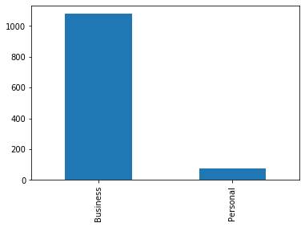

```python
df["CATEGORY*"].value_counts().plot.bar()
```

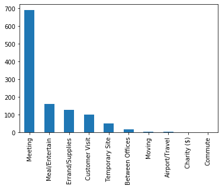

```python
df["PURPOSE*"].value_counts().plot.bar()
```

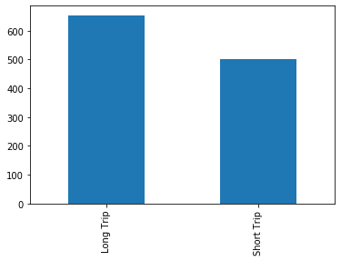

```python
df["miles_cat"].value_counts().plot.bar()
```

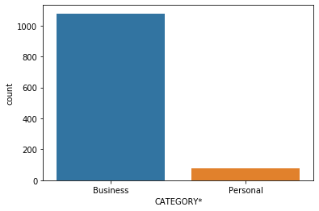

```python
sns.countplot(df['CATEGORY*'])
```

```python
miles_50 = df.loc[df["MILES*"] < 50]
```

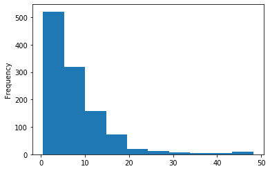

```python
miles_50['MILES*'].plot.hist()
```

```python
df['MILES*'].describe()
```

```
count     1156.000000
mean        21.115398
std        359.299007
min          0.500000
25%          2.900000
50%          6.000000
75%         10.400000
max      12204.700000
Name: MILES*, dtype: float64
```

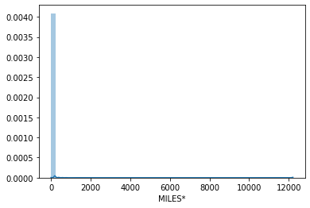

```python
sns.distplot(df["MILES*"] )
```

## bivariate analaysis --> analyse 2 variables at a time

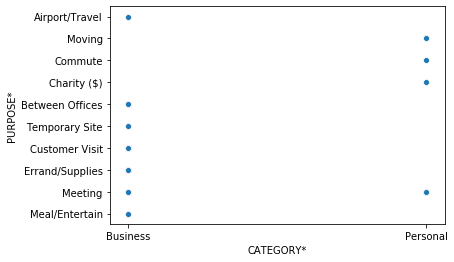

```python
sns.scatterplot(x = "CATEGORY*" , y = "PURPOSE*" , data =df)
```

```python
df.columns
```

```
Index(['START_DATE*', 'END_DATE*', 'CATEGORY*', 'START*', 'STOP*', 'MILES*',
       'PURPOSE*', 'miles_cat'],
      dtype='object')
```